# Comparing Ghani data with ours

2017-03-09

## 0.1 Data steps

The data from Ghani et. al (2015) was converted into a long format panel dataset that now contains the years 2001 and 2011 for the variables on number of factories, employees and output.

The variables were added

## 0.2 Seeing trends across years

First I plot the mean values of the variables across the years.

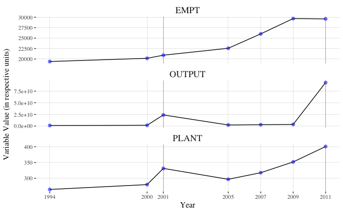

```r
allData %>%
        group_by(year) %>%
        summarise_at(7:9, mean) %>%
        gather(variable, value, 2:4) %>%
        mutate(variable = toupper(variable)) %>%
        ggplot(aes(x = year, y = value)) +
        geom_line() +
        geom_point(colour = "blue", size = 2, alpha = 0.5) +
        geom_vline(xintercept = c(2001, 2011), colour = "red", size = 0.2, alpha = 0.8) +
        facet_wrap(~ variable, ncol = 1, scales = "free_y") +
        scale_x_continuous(breaks = c(1994, 2000, 2001, 2005, 2007, 2009, 2011)) +
        labs(y = "Variable Value (in respective units)", x = "Year") +
        theme_tufte() +
        theme(strip.text = element_text(size = 14), axis.title = element_text(size = 12), panel.grid.major.x = element_line(colour="darkgrey", size=0.1), panel.grid.major.y = element_line(colour="darkgrey", size=0.1))
```

There seems to be a kink in the 2001 data that we have, which probable is driving the results that we are seeing. Also, the value of output seems to have a spike in 2011 (along with 2001) in our data, not sure why that is. I wonder if they are using the same variable as we are. Theirs, seems pretty flat in comparison.

### 0.2.1 Plots by the distance

The first plot shows the mean of the different variable across the distance categories for GQ.

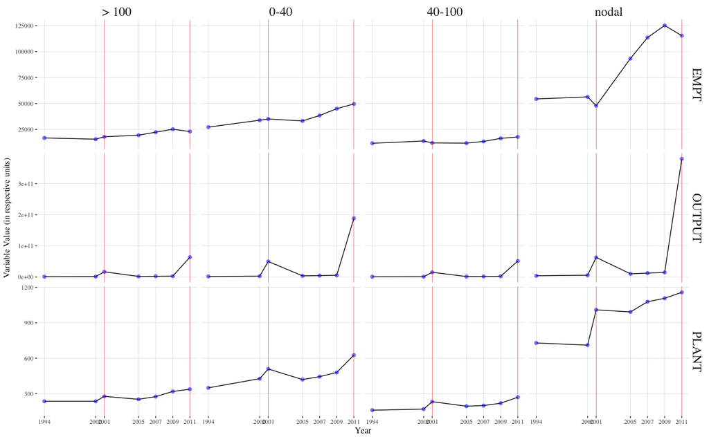

```r
allData %>%
        filter(!is.na(gqDistType)) %>%
        group_by(gqDistType, year) %>%
        summarise_at(7:9, mean) %>%
        gather(variable, value, 3:5) %>%
        mutate(variable = toupper(variable)) %>%
        ggplot(aes(x = year, y = value)) +
        geom_line() +
        geom_point(colour = "blue", size = 2, alpha = 0.5) +
        geom_vline(xintercept = c(2001, 2011), colour = "red", size = 0.2, alpha = 0.8, linetype = 1) +
        facet_grid(variable ~ gqDistType, scales = "free_y") +
        scale_x_continuous(breaks = c(1994, 2000, 2001, 2005, 2007, 2009, 2011)) +
        labs(y = "Variable Value (in respective units)", x = "Year") +
        theme_tufte() +
        theme(strip.text = element_text(size = 18), axis.title = element_text(size = 12), panel.grid.major.x = element_line(colour="darkgrey", size=0.1), panel.grid.major.y = element_line(colour="darkgrey", size=0.1))
```

The next chart is the same as the above, but for NSEW.

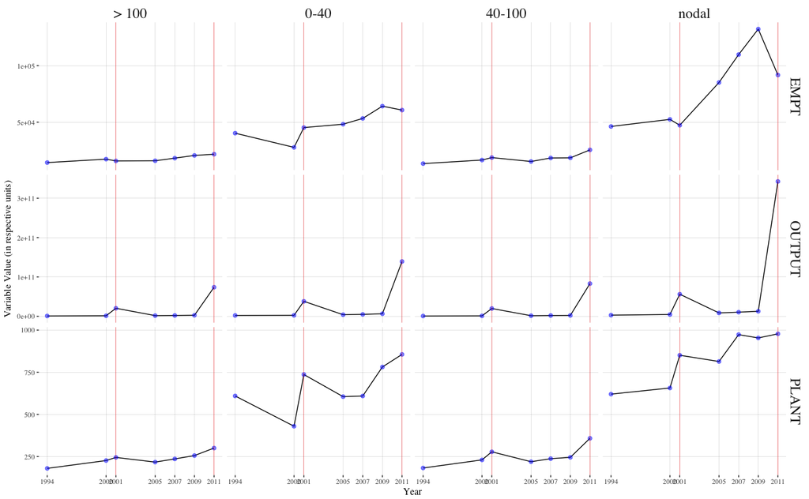

```r
allData %>%
        filter(!is.na(nsewDistType)) %>%
        group_by(nsewDistType, year) %>%
        summarise_at(7:9, mean) %>%
        gather(variable, value, 3:5) %>%
        mutate(variable = toupper(variable)) %>%
        ggplot(aes(x = year, y = value)) +
        geom_line() +
        geom_point(colour = "blue", size = 2, alpha = 0.5) +
        geom_vline(xintercept = c(2001, 2011), colour = "red", size = 0.2, alpha = 0.8, linetype = 1) +
        facet_grid(variable ~ nsewDistType, scales = "free_y") +
        scale_x_continuous(breaks = c(1994, 2000, 2001, 2005, 2007, 2009, 2011)) +
        labs(y = "Variable Value (in respective units)", x = "Year") +
        theme_tufte() +
        theme(strip.text = element_text(size = 18), axis.title = element_text(size = 12), panel.grid.major.x = element_line(colour="darkgrey", size=0.1), panel.grid.major.y = element_line(colour="darkgrey", size=0.1))
```

It seems that the data that we have is inflating the values for both 2001 and 2011 for output, while for the rest of the variables there seems to be kinks around 2001. Employment in nodal cities weirdly drop a bit in nodal districts while the other two variables seem to be higher than the trend.